# Assignment-1: Discharge of Poudre River

AJ Lee

1/27/2022

# Poudre River Overview

The Poudre River is the main source of water for Fort Collins, flowing from the peaks of the Rocky Mountains into the western vast plains. The river travels through a variety of terrain, exhibiting ever-changing quantities that change with the seasons. **By observing the discharge of the Poudre River, I want to understand the characteristics of the river.**

## Site

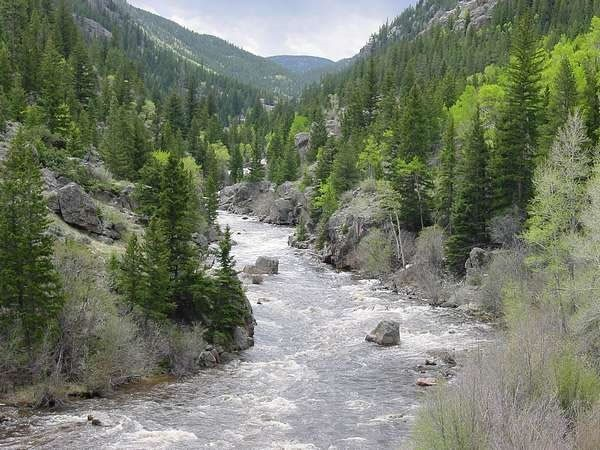

## Data Acquisition and Plotting tests

### Data Download

I collect water discharge data upstream and downstream of Poudre by using NWIS dataset.

```r
Up <- readNWISdv(siteNumbers = '06752260',
                parameterCd = '00060',
                startDate = '2017-01-01',
                endDate = '2020-01-01') %>%
  rename(Q_up = 'X_00060_00003')


Down <- readNWISdv(siteNumbers = '06752280',
                parameterCd = '00060',
                startDate = '2017-01-01',
                endDate = '2020-01-01') %>%
  rename(Q_down = 'X_00060_00003')

River <- merge (Up, Down, by='Date')
```

### Interactive Data Plotter

```r
Up_xts <- xts(River$Q_up, order.by = River$Date)
Down_xts <- xts(River$Q_down, order.by = River$Date)
Discharge <- cbind(Up_xts, Down_xts)
dygraph(Discharge, main = "Discharge of Poudre") %>%
  dySeries("Up_xts", label = "Upstream(cfs)") %>%
  dySeries("Down_xts", label = "Downstream(cfs)") %>%
  dyLegend(show = "always", hideOnMouseOut = FALSE)
```

[interactive chart not shown]

## Conclusions

**The Poudre River has several characteristics as below:**

- The Poudre river tends to decrease its discharge over time. This is probably seemed due to less snow, a major water resource of the Poudre. **Is it the impact of climate change?** [climate change impact](https://www.colorado.edu/ecenter/energy-climate-justice/general-energy-climate-info/climate-change/impacts-colorado)
- *The Flow tends to decrease as going downstream. This is believed to be due to either a runoff of water for cultivating nearby agricultural land or a sharply reduced flow rate as it approaches the plains.*
- Do you know that the main fish that inhabits in the Poudre is Brown trout that is non-native fish ? [Poudre fishing report](https://troutunderground.com/Cache-La-Poudre-River-Fishing-Report/)
- Finally, I think one of the most fun things to do in Poudre is rafting along the rough rivers in summer. If you do not yet, try it this summer. **Have some cool fun in Poudrer**

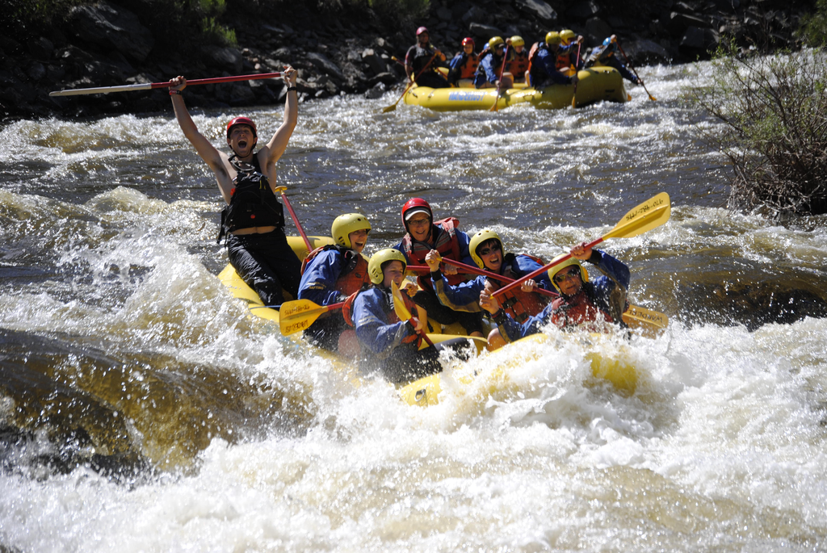